# Breast Cancer Survival in the Rotterdam Tumor Bank

- Show All Code
- Hide All Code
- View Source

Prognostic Factors, Treatment Selection, and Survival Outcomes

Author

Rabbi Tweneboah

**📄 Prefer the concise version?** View the Portfolio research report for a focused summary of the study, key findings, and interpretation.

# 1 Introduction

Breast-cancer survival analyses based on observational clinical data require careful attention to both prognosis and treatment selection. Patients who receive chemotherapy may differ systematically from those who do not with respect to underlying demographic characteristics (including age), tumour burden, receptor status, and other characteristics that are also associated with survival. A crude comparison of survival between treatment groups can therefore reflect differences in baseline risk as well as treatment-related differences.

This project uses the Rotterdam Tumor Bank data available in the `survival` R package to study overall survival among women with primary breast cancer. The analysis is developed in stages. This first stage characterizes the study population, assesses data quality, describes treatment patterns, and evaluates baseline covariate balance between women who received chemotherapy and those who did not. These results establish the empirical foundation for subsequent survival modelling.

The primary exposure is **chemotherapy**, and the primary outcome for the full project is **overall survival**, defined by time to death or censoring. Recurrence outcomes are retained for possible secondary analyses but are not treated as baseline adjustment variables.

# 2 Comprehensive Cohort Description

## 2.1 Study population and variable roles

The Rotterdam data contain one patient-level record for each woman and include baseline demographic characteristics, tumour characteristics, treatment indicators, recurrence follow-up, and mortality follow-up.

Variable dictionary

Rotterdam Tumor Bank cohort

| Variable | Description | Analytical role |
| --- | --- | --- |
| pid | Patient identifier | Identifier |
| year | Year of cancer incidence | Baseline covariate |
| age | Age at incidence | Baseline covariate |
| meno | Menopausal status | Baseline covariate |
| size | Tumour size category | Baseline covariate |
| grade | Tumour grade | Baseline covariate |
| nodes | Number of positive lymph nodes | Baseline covariate |
| pgr | Progesterone receptor level (fmol/L) | Baseline covariate |
| er | Estrogen receptor level (fmol/L) | Baseline covariate |
| hormon | Hormonal treatment | Co-treatment / sensitivity variable |
| chemo | Chemotherapy | Primary exposure |
| rtime | Days to recurrence or last follow-up | Secondary outcome time |
| recur | Recurrence indicator | Secondary event indicator |
| dtime | Days to death or last follow-up | Primary outcome time |
| death | Death indicator | Primary event indicator |

For the chemotherapy–overall-survival analysis, recurrence variables are treated as **post-baseline outcomes**, not as baseline confounders. Hormonal therapy is considered separately because it is a co-treatment rather than a pretreatment patient characteristic.

## 2.2 Data preparation and quality

### 2.2.1 Variable recoding

The raw variables are preserved, while labelled factors and year-scale follow-up variables are created for analysis and presentation.

The reproducible data-preparation workflow is implemented in `R/01_data-preparation.R`. Mortality and recurrence follow-up are converted from days to years, while chemotherapy, menopausal status, tumour grade, hormonal therapy, and tumour size are represented using labelled factors for subsequent analysis. The original source variables remain unchanged.

### 2.2.2 Data-quality checks

The cohort is checked for duplicated patient identifiers, missing values, invalid event indicators, and non-positive follow-up times.

Data-quality assessment

| Diagnostic | Count |
| --- | --- |
| Patient records | 2,982 |
| Unique patient identifiers | 2,982 |
| Duplicated patient identifiers | 0 |
| Total missing values | 0 |
| Variables with any missing values | 0 |
| Invalid death indicators | 0 |
| Invalid recurrence indicators | 0 |
| Non-positive mortality follow-up times | 0 |
| Non-positive recurrence follow-up times | 0 |

The dataset contains 2982 women and 2982 unique patient identifiers. No missing observations are present across the 15 source variables; therefore, no imputation or complete-case exclusion is required for the baseline analysis.

## 2.3 Cohort profile

Cohort profile

| Measure | Value |
| --- | --- |
| Women in cohort | 2,982 |
| Received chemotherapy | 580 (19.5%) |
| Received hormonal therapy | 339 (11.4%) |
| Deaths observed | 1,272 (42.7%) |
| Recurrences observed | 1,518 (50.9%) |
| Median age at incidence | 54 years |
| Median observed mortality follow-up | 7.2 years |

Chemotherapy was received by 580 women (19.5%), while 1272 deaths (42.7%) were observed during mortality follow-up.

## 2.4 Baseline characteristics by chemotherapy status

Baseline balance is evaluated using standardized mean differences (SMDs). Unlike conventional hypothesis tests, SMDs emphasize the **magnitude of covariate imbalance** rather than whether a difference is statistically distinguishable from zero in a large sample. An absolute SMD of 0.10 is used as a descriptive reference point for potentially meaningful imbalance, rather than as a formal significance threshold.

The Stage 1 computational workflow, including construction of the standardized mean differences and the descriptive baseline dataset, is implemented in `R/02_stage1-analysis.R`.

### 2.4.1 Baseline table

Table 1

Baseline characteristics by chemotherapy status

Values are mean (SD), median [IQR], or n (%) as indicated

| Characteristic | Overall | Treatment group No chemotherapy | Treatment group Chemotherapy | Absolute SMD |  |
| --- | --- | --- | --- | --- | --- |
| Age, years — mean (SD) | 55.1 (13.0) | 57.6 (12.8) | 44.7 (7.3) |  | 1.235 |
| Postmenopausal, n (%) | 1,670 (56.0%) | 1,581 (65.8%) | 89 (15.3%) | 1.198 |  |
| Tumour size: ≤20 mm, n (%) | 1,387 (46.5%) | 1,148 (47.8%) | 239 (41.2%) | 0.160 |  |
| Tumour size: 20–50 mm, n (%) | 1,291 (43.3%) | 1,028 (42.8%) | 263 (45.3%) |  |  |
| Tumour size: >50 mm, n (%) | 304 (10.2%) | 226 (9.4%) | 78 (13.4%) |  |  |
| Grade 3 tumour, n (%) | 2,188 (73.4%) | 1,762 (73.4%) | 426 (73.4%) | 0.002 |  |
| Positive lymph nodes — median [IQR] | 1.0 [0.0, 4.0] | 0.0 [0.0, 3.0] | 2.0 [1.0, 5.0] | 0.415 |  |
| Progesterone receptor — median [IQR] | 41.0 [4.0, 198.0] | 38.0 [4.0, 186.0] | 58.5 [8.0, 234.2] | 0.072 |  |
| Estrogen receptor — median [IQR] | 61.0 [11.0, 202.8] | 73.0 [12.0, 234.0] | 40.0 [10.0, 98.2] | 0.362 |  |
| Year of cancer incidence — mean (SD) | 1988.2 (3.0) | 1988.2 (3.0) | 1988.1 (3.2) | 0.012 |  |

SMD = standardized mean difference. The tumour-size SMD summarizes the factor overall and is displayed on the first tumour-size row.

The strongest baseline differences are observed for age, menopausal status, lymph-node involvement, estrogen-receptor levels, and tumour size. Women who received chemotherapy were substantially younger, were much less likely to be postmenopausal, and had greater lymph-node involvement. They also had somewhat larger tumours and lower estrogen-receptor levels. By contrast, tumour grade, progesterone-receptor levels, and year of cancer incidence were comparatively well balanced.

These differences show that chemotherapy recipients and non-recipients are not directly comparable on several important prognostic characteristics. Subsequent survival analyses will therefore distinguish **unadjusted group differences** from covariate-adjusted estimates.

### 2.4.2 Covariate balance

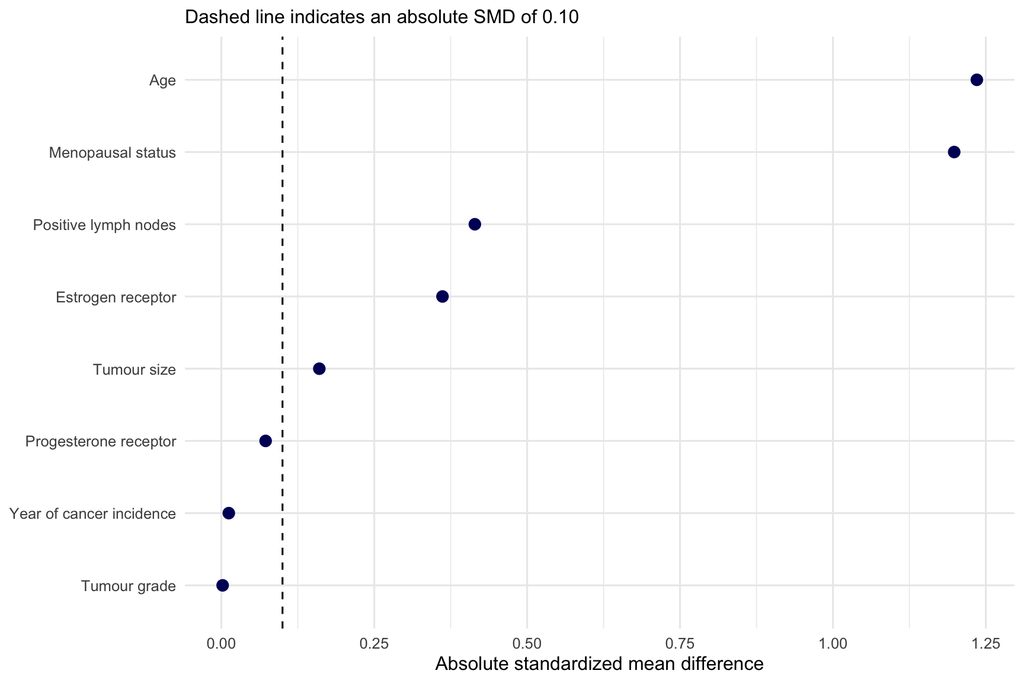

Figure 1: Baseline covariate imbalance by chemotherapy status

```r
balance_labels <- c(
  age = "Age",
  meno_f = "Menopausal status",
  size_f = "Tumour size",
  grade_f = "Tumour grade",
  nodes = "Positive lymph nodes",
  pgr = "Progesterone receptor",
  er = "Estrogen receptor",
  year = "Year of cancer incidence"
)

# Presentation copy: preserve the shared analysis object unchanged
balance_dt <- copy(smd_dt)
balance_dt[, label := unname(balance_labels[variable])]
balance_dt[, abs_smd := abs(smd)]

balance_plot <- ggplot(
  balance_dt,
  aes(
    x = abs_smd,
    y = reorder(label, abs_smd)
  )
) +
  geom_point(size = 3, color = "#006") +
  geom_vline(
    xintercept = 0.10,
    linetype = "dashed"
  ) +
  labs(
    x = "Absolute standardized mean difference",
    y = NULL,
    subtitle = "Dashed line indicates an absolute SMD of 0.10"
  )

balance_plot

# Save reusable figure output
ggsave(
  filename = file.path(
    directory$figures_stage(1),
    "baseline-covariate-balance.png"
  ),
  plot = balance_plot,
  width = 9,
  height = 6,
  dpi = 300
)
```

The balance plot shows particularly large differences in age and menopausal status, followed by lymph-node involvement and estrogen-receptor levels. Age and menopausal status describe closely related aspects of patient profile and will require careful examination when specifying multivariable models.

## 2.5 Treatment patterns over calendar time

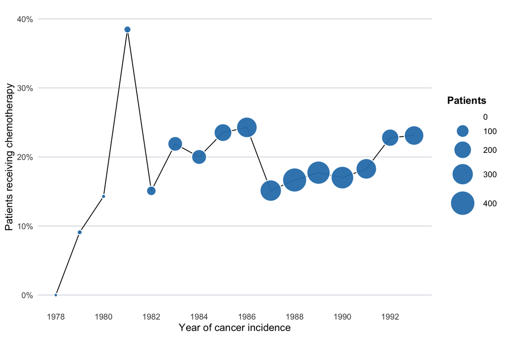

Figure 2: Chemotherapy use over calendar time

```r
chemo_year_plot <- ggplot(
  chemo_by_year,
  aes(x = year, y = chemo_pct)
) +
  geom_line(
    aes(group = 1),
    linewidth = 0.5,
    colour = "black",
    show.legend = FALSE
  ) +
  geom_point(
    aes(size = n),
    shape = 21,
    fill = "#2C7FB8",
    colour = "white",
    stroke = 0.9,
    alpha = 0.95
  ) +
  scale_size_area(
    max_size = 14,
    limits = c(0, 400),
    name = "Patients",
    guide = guide_legend(
      override.aes = list(
        linetype = 0,
        shape = 21,
        fill = "#2C7FB8",
        colour = "white",
        stroke = 0.9
      )
    )
  ) +
  scale_x_continuous(
    breaks = seq(
      min(chemo_by_year$year),
      max(chemo_by_year$year),
      by = 2
    )
  ) +
  scale_y_continuous(
    labels = scales::label_percent(accuracy = 1),
    breaks = seq(0, 0.4, by = 0.1),
    limits = c(0, 0.4)
  ) +
  labs(
    x = "Year of cancer incidence",
    y = "Patients receiving chemotherapy"
  ) +
  theme_minimal(base_size = 13) +
  theme(
    panel.grid.minor = element_blank(),
    panel.grid.major.x = element_blank(),
    panel.grid.major.y = element_line(
      colour = "#D9DDE3",
      linewidth = 0.5
    ),
    legend.position = "right",
    legend.title = element_text(face = "bold")
  )

chemo_year_plot

# Save reusable figure output
ggsave(
  filename = file.path(
    directory$figures_stage(1),
    "chemotherapy-calendar-time.png"
  ),
  plot = chemo_year_plot,
  width = 9,
  height = 6,
  dpi = 300
)
```

Chemotherapy use varied substantially across calendar years, particularly during the earlier period (1978–1987). From the late 1980s onward, use was more stable and generally increased, reaching approximately 23% by 1992–1993. The pronounced fluctuations in the earliest years should be interpreted cautiously because they are based on very small numbers of patients. The small overall standardized difference in year of cancer incidence between treatment groups indicates little imbalance in calendar year between the groups, although calendar year may still be prognostically relevant, warranting its consideration in later survival models.

## 2.6 Co-treatment patterns

Hormonal therapy is summarized separately because it is another treatment indicator rather than an intrinsic baseline patient or tumour characteristic.

Table 2

Hormonal therapy by chemotherapy status

| Chemotherapy status | Patients | Hormonal therapy, n | Hormonal therapy, % |
| --- | --- | --- | --- |
| No chemotherapy | 2,402 | 311 | 12.9% |
| Chemotherapy | 580 | 28 | 4.8% |

Hormonal therapy was less common among women who received chemotherapy than among those who did not. Accordingly, hormonal therapy is not included in the primary assessment of baseline covariate balance. Its potential influence as a co-treatment will be examined separately in sensitivity analyses of survival.

## 2.7 Baseline assessment summary

The Rotterdam cohort provides a complete patient-level dataset with no missing observations in the available variables. Approximately 19.5% of women received chemotherapy.

Baseline comparisons reveal substantial treatment-group imbalance consistent with non-random treatment allocation. Chemotherapy recipients were markedly younger and much less likely to be postmenopausal, yet they also had greater lymph-node involvement, somewhat larger tumours, and lower estrogen-receptor levels. Tumour grade, progesterone-receptor levels, and calendar year were comparatively balanced.

Taken together, these findings motivate the analytical sequence to be used in the remainder of the project. Survival will first be described without adjustment using Kaplan–Meier methods. Multivariable survival models will then assess how the estimated chemotherapy–survival association changes after adjustment for measured baseline prognostic factors, with alternative modelling approaches subsequently used to examine the sensitivity of the findings to model specification and assumptions.

# 3 Non-parametric survival analysis

This layer of the analysis is dedicated to the exploration of observed survival experience amongst primary breast cancer patients. Stage 1 showed substantial baseline differences between women who received chemotherapy and those who did not. Stage 2 therefore focuses on **unadjusted survival patterns** in the cohort.

## 3.1 Follow-up and overall survival

Potential follow-up was characterized using the **reverse Kaplan–Meier method**, which treats deaths as censored observations and administrative censoring as the event. This approach is preferable to reporting the ordinary median of observed follow-up times because it accounts appropriately for censoring.

Cohort-level follow-up and survival summary

Kaplan–Meier estimates with 95% confidence intervals

| Measure | Estimate | 95% CI lower | 95% CI upper |
| --- | --- | --- | --- |
| Median potential follow-up | 9.27 | 9.11 | 9.44 |
| Median overall survival | 11.04 | 10.64 | 11.80 |

Median potential follow-up was approximately 9.27 years (95% CI: 9.11–9.44). During mortality follow-up, 1,272 deaths were observed among 2,982 women. The median overall survival was approximately 11.04 years (95% CI: 10.64–11.8).

## 3.2 Kaplan–Meier curves

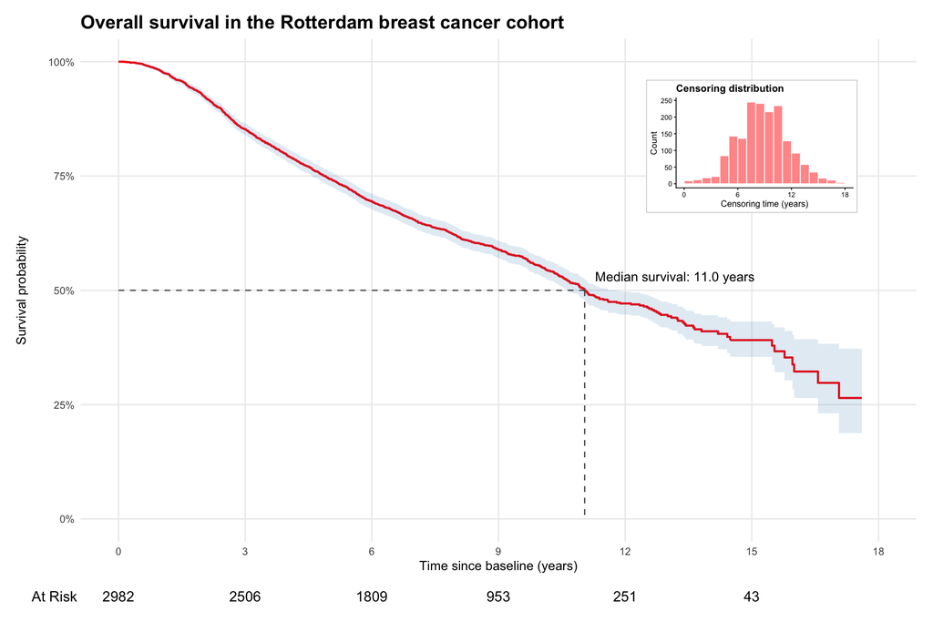

Kaplan-Meier survival probability curve (Overall)

```r
# ------------------------------------------------------------
# Kaplan–Meier  Censoring Distribution
# ------------------------------------------------------------

# Censoring histogram
censor_grob <- ggplotGrob(
  ggplot(dt[death == 0], aes(dtime_yrs)) +
    geom_histogram(
      binwidth = 1, boundary = 0,
      fill = "#FF9999", colour = "white"
    ) +
    scale_x_continuous(
      breaks = c(0, 6, 12, 18),
      limits = c(0, 18)
    ) +
    labs(
      title = "Censoring distribution",
      x = "Censoring time (years)",
      y = "Count"
    ) +
    theme_classic(base_size = 6) +
    theme(
      plot.title = element_text(size = 7, face = "bold"),
      plot.background = element_rect(
        colour = "#B0B0B0",
        linewidth = 0.3
      )
    )
)

# ------------------------------------------------------------
# Kaplan–Meier  Curve
# ------------------------------------------------------------
overall_km_plot <- ggsurvfit(
  km_overall_fit,
  linewidth = 0.7,
  colour = "red"
) +
  add_confidence_interval(
    fill = "#2C7FB8",
    alpha = 0.15
  ) +
  add_quantile(
    y_value = 0.5,
    colour = "#555555",
    linetype = "dashed"
  ) +
  add_risktable(
    risktable_stats = "n.risk",
    times = seq(0, 15, 3)
  ) +
  annotate(
    "text",
    x = km_overall$median + 0.25,
    y = 0.53,
    label = sprintf(
      "Median survival: %.1f years",
      km_overall$median
    ),
    hjust = 0,
    size = 3.2
  ) +
  annotation_custom(
    censor_grob,
    xmin = 12.5, xmax = 17.5,
    ymin = 0.67, ymax = 0.96
  ) +
  scale_x_continuous(
    breaks = seq(0, 18, 3),
    limits = c(0, 18)
  ) +
  scale_y_continuous(
    breaks = seq(0, 1, 0.25),
    labels = scales::label_percent(),
    limits = c(0, 1)
  ) +
  labs(
    title = "Overall survival in the Rotterdam breast cancer cohort",
    x = "Time since baseline (years)",
    y = "Survival probability"
  ) +
  theme_minimal(base_size = 9) +
  theme(
    plot.title = element_text(face = "bold", size = 13),
    panel.grid.minor = element_blank(),
    legend.position = "none"
  )


ggsave(
  filename = file.path(
    directory$figures_stage(2),
    "overall-kaplan-meier.png"
  ),
  plot = overall_km_plot,
  width = 9,
  height = 6,
  dpi = 300
)

overall_km_plot
```

Overall survival declined progressively over follow-up, with an estimated median survival of approximately 11` years. Survival remained comparatively high during the early follow-up period before declining more steadily over subsequent years. Precision decreased toward the end of follow-up as the risk set became substantially smaller; only 251 women remained at risk at approximately 12 years and 43 at 15 years. Censoring occurred predominantly during the middle-to-later years of follow-up, contributing to the declining number at risk and increasing uncertainty in the tail of the Kaplan–Meier curve.

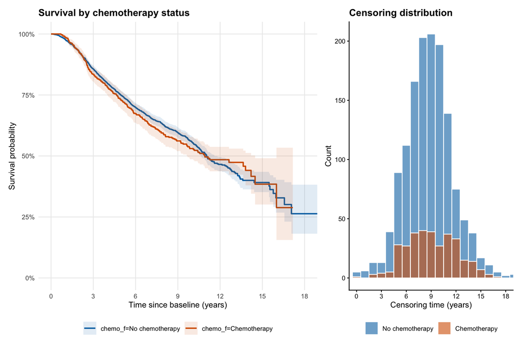

Kaplan-Meier survival probability curve (Subgroups)

```r
cols <- c("#0072B2", "#D55E00")
p1 <- ggsurvfit(km_chemo_fit, linewidth = 0.8) +
  add_confidence_interval(alpha = 0.12) +
  scale_colour_manual(values = cols) +
  scale_fill_manual(values = cols) +
  coord_cartesian(xlim = c(0, 18), ylim = c(0, 1)) +
  scale_x_continuous(breaks = seq(0, 18, 3)) +
  scale_y_continuous(
    breaks = seq(0, 1, 0.25),
    labels = scales::label_percent()
  ) +
  labs(
    title = "Survival by chemotherapy status",
    x = "Time since baseline (years)",
    y = "Survival probability",
    colour = NULL,
    fill = NULL
  ) +
  theme_minimal(base_size = 10) +
  theme(
    plot.title = element_text(face = "bold"),
    panel.grid.minor = element_blank(),
    legend.position = "bottom"
  )

# Censoring distributions
p2 <- ggplot(
  dt[death == 0],
  aes(dtime_yrs, fill = chemo_f)
) +
  geom_histogram(
    binwidth = 1,
    position = "identity",
    alpha = 0.6,
    colour = "white"
  ) +
  scale_fill_manual(values = cols) +
  coord_cartesian(xlim = c(0, 18)) +
  scale_x_continuous(breaks = seq(0, 18, 3)) +
  labs(
    title = "Censoring distribution",
    x = "Censoring time (years)",
    y = "Count",
    fill = NULL
  ) +
  theme_classic(base_size = 10) +
  theme(
    plot.title = element_text(face = "bold"),
    legend.position = "bottom"
  )

# Side-by-side plot
chemo_km_plot <- p1 + p2 + plot_layout(widths = c(1.7, 1))

ggsave(
  filename = file.path(
  directory$figures_stage(2),
  "km_chemo.png"
  ),
  plot = chemo_km_plot,
  width = 12,
  height = 5,
  dpi = 300
)

chemo_km_plot
```

Kaplan–Meier survival curves stratified by chemotherapy status showed substantial overlap across follow-up, with no clear or sustained separation between treatment groups. Survival among chemotherapy recipients was slightly lower during portions of the intermediate follow-up period, although the curves later converged and crossed. Confidence intervals overlapped extensively and widened considerably in the tail, particularly for the chemotherapy group, where fewer women remained under observation.

## 3.3 Landmark survival probabilities

Landmark survival probabilities

Overall and chemotherapy-group estimates

| Years | Overall cohort Survival | Overall cohort At risk | No chemotherapy Survival | No chemotherapy At risk | Chemotherapy Survival | Chemotherapy At risk | Difference (pp) |  |
| --- | --- | --- | --- | --- | --- | --- | --- | --- |
| 1 | 98.0% [97.5–98.5] | 2914 | 97.8% [97.2–98.4] | 2342 | 98.8% [97.9–99.7] | 572 |  | 1.0 |
| 5 | 74.4% [72.8–76.0] | 2084 | 74.7% [73.0–76.5] | 1685 | 72.8% [69.2–76.5] | 399 | −2.0 |  |
| 10 | 55.2% [53.2–57.3] | 685 | 55.7% [53.5–58.1] | 544 | 53.0% [48.7–57.8] | 141 | −2.7 |  |
| 15 | 39.1% [35.4–43.2] | 43 | 39.1% [35.2–43.5] | 34 | 38.4% [30.1–49.1] | 9 | −0.7 |  |

Difference = chemotherapy minus no chemotherapy; pp = percentage points.

It can be observed that across landmarked periods survival of primary breast cancer (overall; by chemotherapy status) declined progressively over follow-up. At year 1, estimated survival was slightly higher among women who received chemotherapy. At 5 and 10 years, the chemotherapy group had slightly lower survival, while the 15-year estimates were very similar. These absolute differences were small and statistically negligible throughout.

## 3.4 Median survival by treatment status

Median survival by chemotherapy status

Kaplan–Meier estimates with 95% confidence intervals

| Chemotherapy status | N | Deaths | Median survival (years) | 95% CI lower | 95% CI upper |
| --- | --- | --- | --- | --- | --- |
| No chemotherapy | 2,402 | 1,014 | 11.04 | 10.64 | 11.61 |
| Chemotherapy | 580 | 258 | 10.92 | 9.64 | 14.49 |

Median survival was approximately 11.04 years among women who did not receive chemotherapy and 10.92 years among women who did.

## 3.5 Reproducibility

The Rotterdam data are distributed with the `survival` R package, so no external data download is required.